# Labo 2: Game of Life de Conway

#### Formal and Natural Languages (FNL) - 1.8

26.02.2025

## Objectifs

Le **jeu de la vie** (*game of life*) de Conway est un **automate cellulaire** qui fait évoluer une grille bidimensionnelle de cellules selon des règles simples. À partir d’un code de simulation, vous allez :

1. extraire et comprendre les **règles de survie (et de mort)** qui ont été implémentées dans le code.
2. modifier cette simulation pour mettre en place un **autre pattern** connu, ici le *planeur*.
3. tester et expérimenter, en groupe, d’autres patterns afin d’observer leurs évolutions.

Vous n’allez par contre **pas** regarder sur internet ce qu’est ce jeu de la vie etc., car ça vous gâcherait le plaisir de découvrir et d’apprendre de ce labo 😉.

La durée estimée pour réaliser ce laboratoire est de **1 période**. Cette donnée se trouve sous forme électronique sur le [site web du cours](https://isc.hevs.ch/learn/).

# Partie 1 : Analyse du code et comprendre les “règles de survie”

## Etape 1 : Présentation du code de base

Vous disposez d’un script Python qui simule le Game of Life: game_of_life.py

1. Analysez la fonction `count_neighbors`. Que fait-elle?
2. Dans `update_grid`, comment comprenez-vous les “Règles de survies”?

**Afficher la solution**

#### 1. La fonction `count_neighbors`

`count_neighbors` compte les cellules *vivantes* autour d’une cellule donnée.

#### 2. Règles de survie:

Pour une cellule **vivante** (`if grid[i][j] == 1`) :

- La cellule survit si elle possède 2 ou 3 voisins vivants.
- Sinon, elle meurt (surpopulation ou isolement).

Pour une cellule **morte** :

- Elle naît (devient vivante) si elle a exactement 3 voisins vivants.

## Etape 2 : Représentation sous forme d’automate

Représentez les “Règles de survie” sous forme d’automate (avec des états et des transitions entre ces états).

**Afficher la solution**

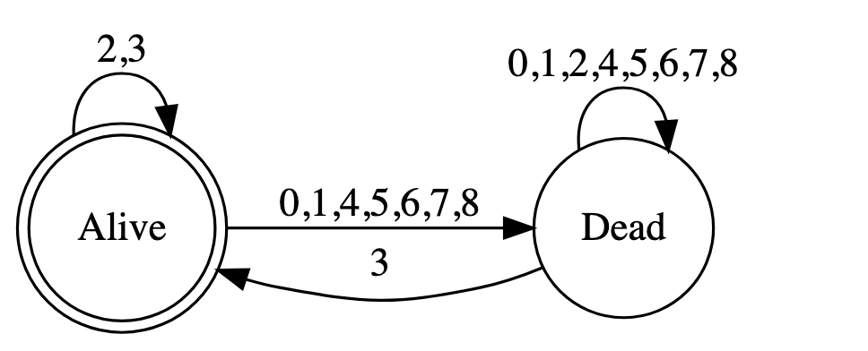

Automate pour le Jeu de la Vie, avec les labels des transitions correspondant au nombres de voisins vivants

# Partie 2 : Créer de nouveaux patterns

## Etape 1 : Créer un planeur

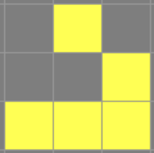

Le planeur (*glider*) est l’un des patterns les plus célèbres du Game of Life. Il se *déplace* en diagonale au fil des générations. Le planeur est constitué de 5 cellules disposées de la façon suivante (coordonnées relatives) :

- (0,1)
- (1,2)
- (2,0)
- (2,1)
- (2,2)

Ou, sous forme visuelle :

```
     0 1 0
     0 0 1
     1 1 1         (1 = cellule vivante)
```

Modifiez maintenant votre fonction `initialize_grid` par une nouvelle version qui créera un glider. Par exemple, vous pouvez positionner le glider en haut à gauche de la grille.

**Afficher la solution**

```python
def initialize_grid(grid):
    # place un glider en haut à gauche.
    # on utilise des indices (ligne, colonne).
    grid[0][1] = 1
    grid[1][2] = 1
    grid[2][0] = 1
    grid[2][1] = 1
    grid[2][2] = 1
```

Exécutez votre programme et observez l’évolution du glider. Notez particulièrement sa translation et son comportement cyclique. Combien de *phases différentes* le glider a-t-il?

**Afficher la solution**

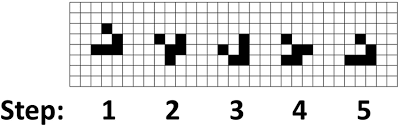

Phases du glider

## Etape 2: Le bloc stable

Le *bloc stable* est une configuration 2×2 de cellules vivantes qui, une fois en place, ne changent plus. Voici son schéma :

```
  1 1
  1 1
```

Modifiez à nouveau `initialize_grid` (positionnez le bloc par exemple en (4, 4))

**Afficher la solution**

```python
def initialize_grid(grid):
    # place le bloc en position (4,4)
    grid[4][4] = 1
    grid[4][5] = 1
    grid[5][4] = 1
    grid[5][5] = 1
```

Pourquoi le block reste-t-il stable sur toutes les générations?

## Etape 3: La ruche

La ruche (*beehive*) est un autre motif stable. Sa configuration ressemble à une forme elliptique.

```
 0 1 1 0
 1 0 0 1
 0 1 1 0
```

Voici un exemple de code pour la ruche:

```python
def initialize_grid(grid):
    # place la ruche en position (4,4)
    grid[4][5] = 1
    grid[4][6] = 1
    grid[5][4] = 1
    grid[5][7] = 1
    grid[6][5] = 1
    grid[6][6] = 1
```

## Etape 4: Le toad (oscillateur de période 2)

Le toad est un oscillateur constitué de 6 cellules qui alterne entre deux configurations.

```
  0 1 1 1
  1 1 1 0
```

Voici un exemple de code pour le toad:

```python
def initialize_grid(grid):
    # place le toad en position (4,4)
    grid[4][5] = 1
    grid[4][6] = 1
    grid[4][7] = 1
    grid[5][4] = 1
    grid[5][5] = 1
    grid[5][6] = 1
```

Notez que le *toad* alterne entre deux formes toutes les générations (période 2).

## Etape 5: Le pulsar (oscillateur de période 3)

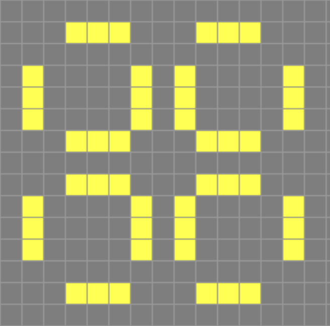

Le *pulsar* est un oscillateur plus grand composé de 48 cellules. Il alterne son apparence en trois phases. Le pulsar se compose de “bras” de 3 cellules disposés symétriquement autour d’un centre vide.

Exemple de code pour le pulsar:

```python
def initialize_grid(grid):
    # première rangée horizontale de bras
    grid[2][4] = 1; grid[2][5] = 1; grid[2][6] = 1
    grid[2][10] = 1; grid[2][11] = 1; grid[2][12] = 1
    # partie haute
    grid[4][2] = 1; grid[4][7] = 1; grid[4][9] = 1; grid[4][14] = 1
    grid[5][2] = 1; grid[5][7] = 1; grid[5][9] = 1; grid[5][14] = 1
    grid[6][2] = 1; grid[6][7] = 1; grid[6][9] = 1; grid[6][14] = 1
    # partie basse symétrique
    grid[7][4] = 1; grid[7][5] = 1; grid[7][6] = 1; grid[7][10] = 1; grid[7][11] = 1; grid[7][12] = 1
    grid[9][4] = 1; grid[9][5] = 1; grid[9][6] = 1; grid[9][10] = 1; grid[9][11] = 1; grid[9][12] = 1
    grid[10][2] = 1; grid[10][7] = 1; grid[10][9] = 1; grid[10][14] = 1
    grid[11][2] = 1; grid[11][7] = 1; grid[11][9] = 1; grid[11][14] = 1
    grid[12][2] = 1; grid[12][7] = 1; grid[12][9] = 1; grid[12][14] = 1
    # rangée horizontale basse (mi-oscillation)
    grid[14][4] = 1; grid[14][5] = 1; grid[14][6] = 1; grid[14][10] = 1; grid[14][11] = 1; grid[14][12] = 1
```

Testez et observez l’alternance de la configuration du pulsar qui se répète toutes les 3 générations.

# Partie 3 : Expérimenter dans un GUI

Mettez-vous maintenant en groupe de 2 à 4 personnes de votre choix et expérimentez avec de nouveaux pattern. Je vous propose d’utiliser un GUI comme [playgameoflife.com](https://playgameoflife.com/) pour experimenter rapidement avec d’autres pattern.

Essayez de créer vos propres des patterns, et observez leur évolution.

Vous pouvez aussi cliquer sur “Lexicon” pour voir des patterns célèbres.

Et sinon pour finir:

*Explore the infinitely recursive universe of Game of Life! Works in real-time and is perfectly consistent, never fails to remember where you are and where you came from.*

Simulation: oimo.io/works/life/

[Explication](https://blog.oimo.io/2023/04/10/life-universe-en/)

[figure not shown]